# Reproducible Research Peer Assignement 1

Dataset: [Activity monitoring data](https://d396qusza40orc.cloudfront.net/repdata%2Fdata%2Factivity.zip) [52K]

The variables included in this dataset are:

1. steps: Number of steps taking in a 5-minute interval (missing values are coded as `NA`)
2. date: The date on which the measurement was taken in YYYY-MM-DD format
3. interval: Identifier for the 5-minute interval in which measurement was taken

The dataset is stored in a comma-separated-value (CSV) file and there are a total of 17,568 observations in this dataset.

## Part 1: Loading and preprocessing the data

```r
data <- read.csv("~/mm/activity.csv",  colClasses = c("numeric", "character",
                                                          "numeric"))
```

- Calculate the aggregate steps for all intervals sorted by day
- Plot Total Steps by Day
- Look for the interval with most steps.

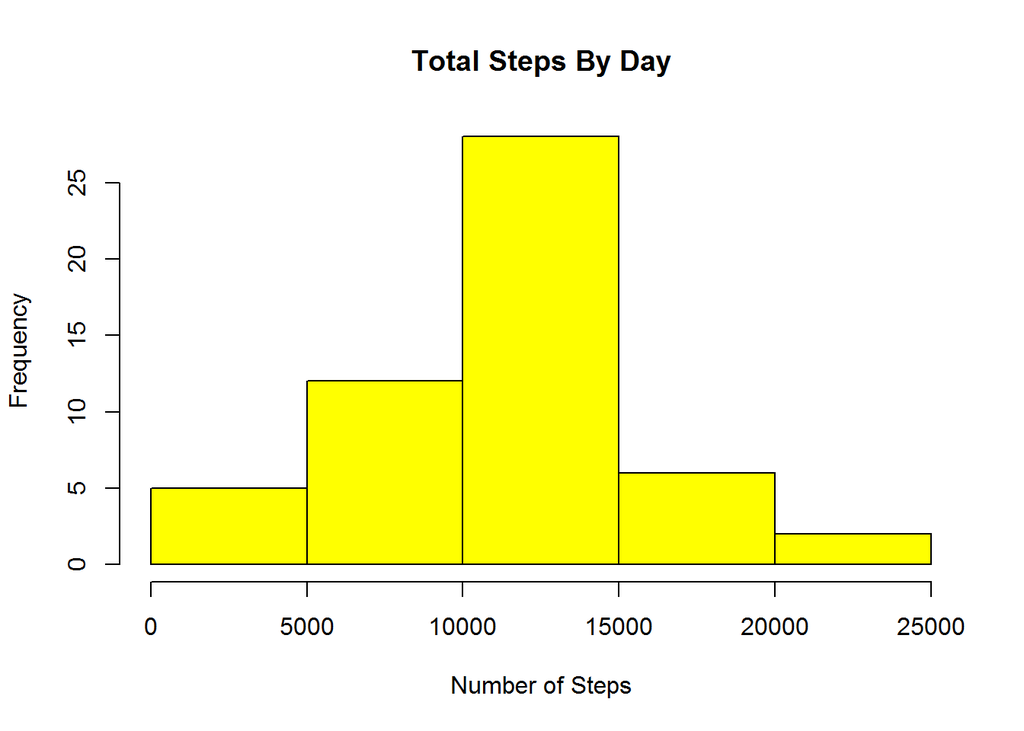

```r
StepsTotal <- aggregate(steps ~ interval, data, mean)
dailysteps <- aggregate(steps~date,data,sum)

hist(dailysteps$steps, main = "Total Steps By Day", xlab = "Number of Steps", col = "yellow")
```

```r
max_interval <- StepsTotal[which.max(StepsTotal$steps),1]
```

## Part 3: What is the average daily activity pattern?

### Use time series plot to check 5 minute intervals

The 5-minute interval, on average across all the days in the data set, containing the maximum number of steps is 835.

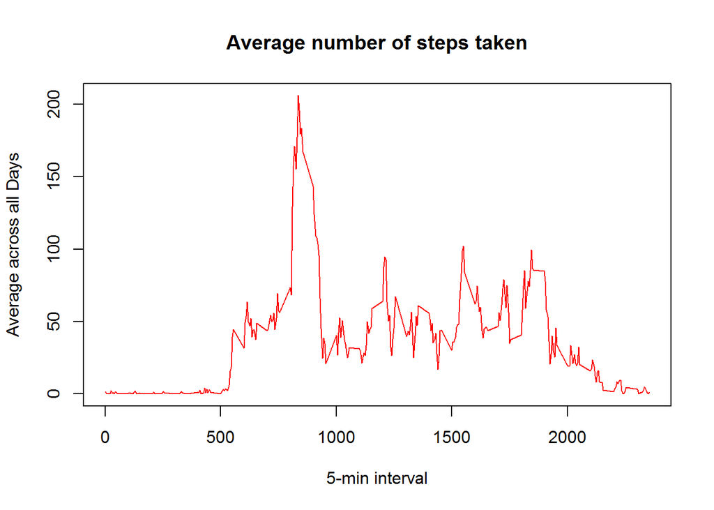

```r
time_series <- tapply(activity$steps, activity$interval, mean, na.rm = TRUE)

##And plot:
plot(row.names(time_series), time_series, type = "l", xlab = "5-min interval",
     ylab = "Average across all Days", main = "Average number of steps taken",
     col = "red")
```

```r
## to find max number of steps on average in a 5 min interval
max_interval <- which.max(time_series)
names(max_interval)
```

```
## [1] "835"
```

## Part 4: Imputing missing values

```r
empty <-sum(!complete.cases(data))
newdata <- transform(data, steps = ifelse(is.na(data$steps), StepsTotal$steps[match(data$interval, StepsTotal$interval)], data$steps))
newdata[as.character(newdata$date) == "2012-10-01", 1] <- 0
```

So now with the filled in data, we can recount the information given.

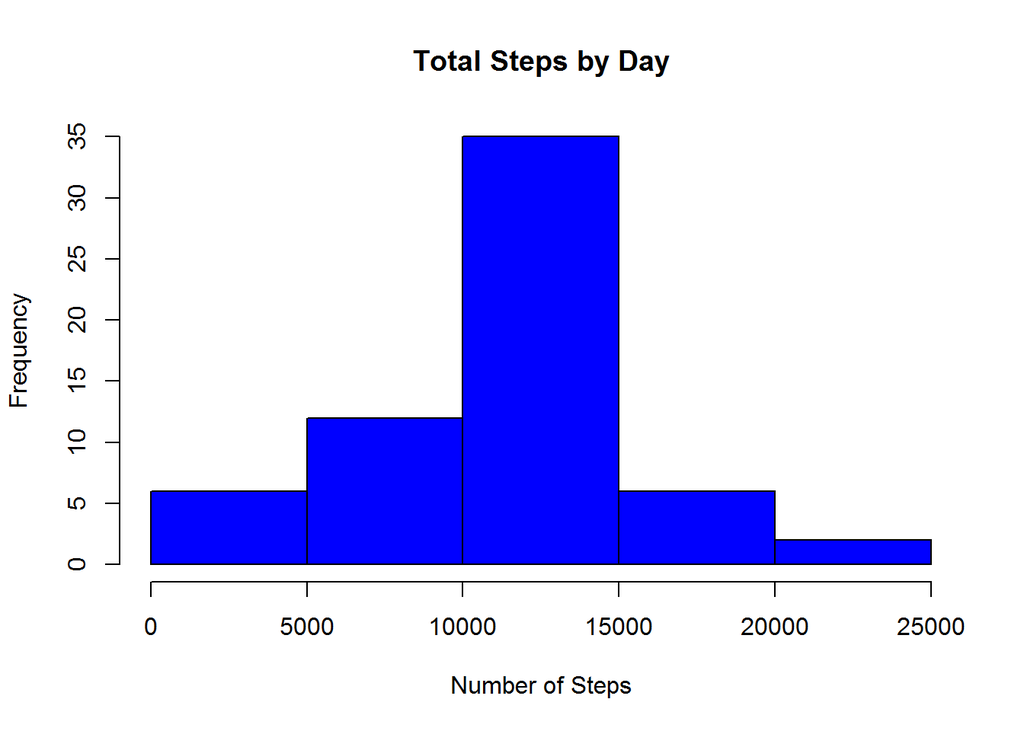

```r
dailysteps.2 <- aggregate(steps~date,newdata,sum)
hist(dailysteps.2$steps, main = "Total Steps by Day", xlab = "Number of Steps", col="blue")
```

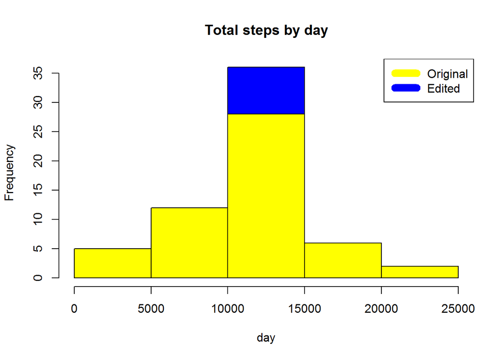

```r
StepsTotal2 <- aggregate(steps ~ date, data = new_activity, sum, na.rm = TRUE)
hist(StepsTotal2$steps, main = "Total steps by day", xlab = "day", col = "blue")

## To make it more comparable, here is a display of the changes that occurred due to the removal of "NA" figures, as shown in the blue parts in the histogram.
hist(dailysteps$steps, main = paste("Total Steps Each Day"), col="yellow", xlab="Number of Steps", add=T)
legend("topright", c("Original","Edited"), col=c("yellow", "blue"), lwd=10)
```

```r
##New Mean and median

mean(dailysteps.2$steps)
```

```
## [1] 10589.69
```

```r
median(dailysteps.2$steps)
```

```
## [1] 10766.19
```

change in mean and median

```r
change1<- mean(dailysteps.2$steps) - mean(dailysteps$steps)
print(change1)
```

```
## [1] -176.4949
```

```r
change2<- median(dailysteps.2$steps) - median(dailysteps$steps)
print(change2)
```

```
## [1] 1.188679
```

```r
change3 <- sum(dailysteps.2$steps) - sum(dailysteps$steps)
print(change3)
```

```
## [1] 75363.32
```

The mean when edited has decreased by 176, while the median increased by 1.18. There has also been 75363 steps added when the data is changed.